# Should I shower before bedtime?

Author

Ullrika

Published

November 25, 2025

## Introduction

Haghayegh et al. (2019) performed a Systematic Review and Meta-Analysis asking if Before-bedtime passive body heating by warm shower or bath to improve sleep.

To support individual decision making, my aim is to reproduce meta-analysis from Haghayegh et al. (2019) and embed it into a decision analysis.

- *Reproducibility*: Same data – same analysis

Run a frequentist meta-analysis using a random effects model in the `metafor` package in R (Viechtbauer 2010)

- *Robustness*: Same data – different analysis

Run a Bayesian meta-analysis using a random effects model in `brms` package in R (Bürkner 2017)

- Integrate results into a decision analysis

## Load libraries

```r
library(readr) # For reading in csv-file
library(dplyr) # Manage writing, figures and tables
library(ggplot2) # For plotting

library(metafor) # Frequentist meta-analysis

library(brms) # Bayesian meta-analysis
```

## Response variable

Sleep Onset Latency

The time it takes a person to fall asleep after turning the lights out.

On average, a healthy person takes between 10 and 20 minutes to fall asleep.

Improved sleep corresponds to a shorter SOL

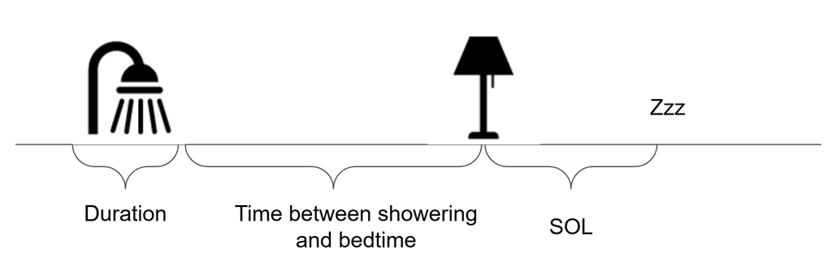

## Model

A meta-analysis is a statistical analysis of multiple studies conducted in a similar way.

Let $\mu$ be the overall effect size. This is the quantity of interest for the analysis.

Each of the eleven studies resulted in an estimate $y_i$ and an estimation error $se_i$, where $i = 1,\ldots,11$.

The estimated effect size for every study is modeled as drawn from a normal distribution with the study specific effect size as the expected value and the estimation error as standard deviation

$$y_i \sim N(\theta_i,se_i)$$

Effect size for study $i$ is modeled as drawn from a normal distribution with expected value $\mu$ and standard deviation $\tau$.

$$\theta_i \sim N(\mu,\tau)$$

The standard deviation $\tau$ denotes the between-study heterogeneity.

## Results from publication

Haghayegh et al. (2019) estimated the overall effect size to be $\hat{\mu} = -0.43$ with a 95% confidence interval $CI: (-0.76,-0.1)$

## Read in data

```r
(sol <- read_csv("data/sol.csv") %>%
  mutate(se = (upper_bound-lower_bound)/(2*qnorm(0.975)))) # calculate standard error from 95% confidence interval
```

```
# A tibble: 11 × 7
   Study                         Year     y lower_bound upper_bound     n    se
   <chr>                        <dbl> <dbl>       <dbl>       <dbl> <dbl> <dbl>
 1 Chiu et al 2017               2017 -1.15       -1.78       -0.53    23 0.319
 2 Dowdell and Javaheri 1992     1992 -0.02       -1.07        1.03     7 0.536
 3 Furushima et al 2009          2009 -0.41       -1.3         0.47    10 0.452
 4 Horne and Reid 1985           1985 -0.29       -1.43        0.84     6 0.579
 5 Jordan et al 1990             1990  0          -1.24        1.24     5 0.633
 6 Liao et al 2008               2008 -0.33       -1.05        0.39    15 0.367
 7 Liao et al 2013               2013  0.39       -0.17        0.95    25 0.286
 8 Mishima et al 2005            2005 -0.77       -1.57        0.03    13 0.408
 9 Sung and Tochihara 2000 body  2000 -0.89       -1.86        0.08     9 0.495
10 Sung and Tochihara 2000 feet  2000 -0.72       -1.67        0.24     9 0.487
11 Withworth-Turner et al 2017   2017 -0.47       -1.31        0.38    11 0.431
```

## Frequentist meta-analysis

For a frequentist version of meta-analysis we use the `metafor` package in R (Viechtbauer 2010)

### Run analysis

```r
rmod <- rma(yi=y,sei=se,data=sol,method="REML")
summary(rmod)
```

```
Random-Effects Model (k = 11; tau^2 estimator: REML)

  logLik  deviance       AIC       BIC      AICc
 -7.4405   14.8811   18.8811   19.4862   20.5954

tau^2 (estimated amount of total heterogeneity): 0.1247 (SE = 0.1379)
tau (square root of estimated tau^2 value):      0.3532
I^2 (total heterogeneity / total variability):   41.06%
H^2 (total variability / sampling variability):  1.70

Test for Heterogeneity:
Q(df = 10) = 16.4077, p-val = 0.0885

Model Results:

estimate      se     zval    pval    ci.lb    ci.ub
 -0.4295  0.1696  -2.5330  0.0113  -0.7618  -0.0972  *

---
Signif. codes:  0 '***' 0.001 '**' 0.01 '*' 0.05 '.' 0.1 ' ' 1
```

### Make forest plot

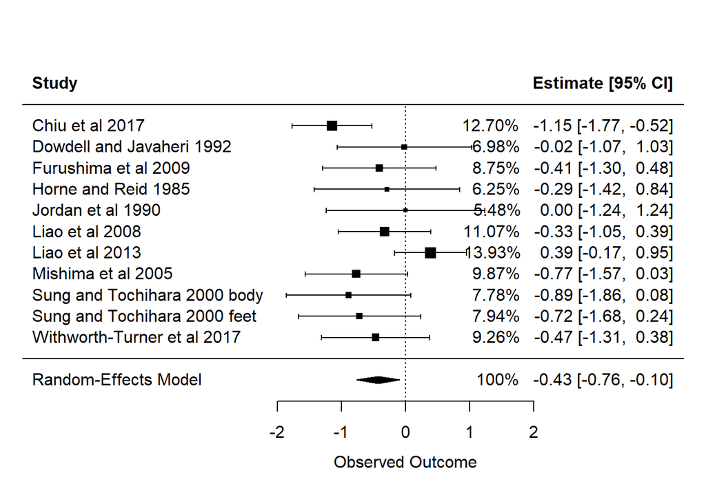

Figure 1: Forest plot of standardized mean difference (Cohen’s d) between treatment and baseline nights of sleep onset latency (SOL). Results are shown as effect size (ES) and 95% confidence interval (CI). Size of the individual symbol markers is indicative of the weight of the respective studies.

```r
forest(rmod,slab=sol$Study,showweights = TRUE)
```

## Bayesian meta-analysis

We reproduce the meta-analysis in a Bayesian framwork by running the random effects model was run in `brms` (Bürkner 2017).

### Run analysis with default prior

```r
bmod <- brm(y|se(se) ~ 1 + (1|Study),
             data = sol,
             chains = 4, # number of chains in mcmc sampline
             iter = 4000, # number of iterations in mcmc sampling
             file = "models/bmod_default_priors") # model is saved to a file to avoid sampling every time document is rendered. To overrun a saved file, one has to first manually delete it
```

```r
(s_bmod <- summary(bmod)) # we use parentheses to show the results at the same time it is saved into an object
```

```
 Family: gaussian
  Links: mu = identity; sigma = identity
Formula: y | se(se) ~ 1 + (1 | Study)
   Data: sol (Number of observations: 11)
  Draws: 4 chains, each with iter = 4000; warmup = 2000; thin = 1;
         total post-warmup draws = 8000

Multilevel Hyperparameters:
~Study (Number of levels: 11)
              Estimate Est.Error l-95% CI u-95% CI Rhat Bulk_ESS Tail_ESS
sd(Intercept)     0.40      0.20     0.05     0.84 1.00     2356     1715

Regression Coefficients:
          Estimate Est.Error l-95% CI u-95% CI Rhat Bulk_ESS Tail_ESS
Intercept    -0.43      0.19    -0.81    -0.07 1.00     4133     3751

Further Distributional Parameters:
      Estimate Est.Error l-95% CI u-95% CI Rhat Bulk_ESS Tail_ESS
sigma     0.00      0.00     0.00     0.00   NA       NA       NA

Draws were sampled using sampling(NUTS). For each parameter, Bulk_ESS
and Tail_ESS are effective sample size measures, and Rhat is the potential
scale reduction factor on split chains (at convergence, Rhat = 1).
```

### Various plotting to check convergence

```
No divergences to plot.
```

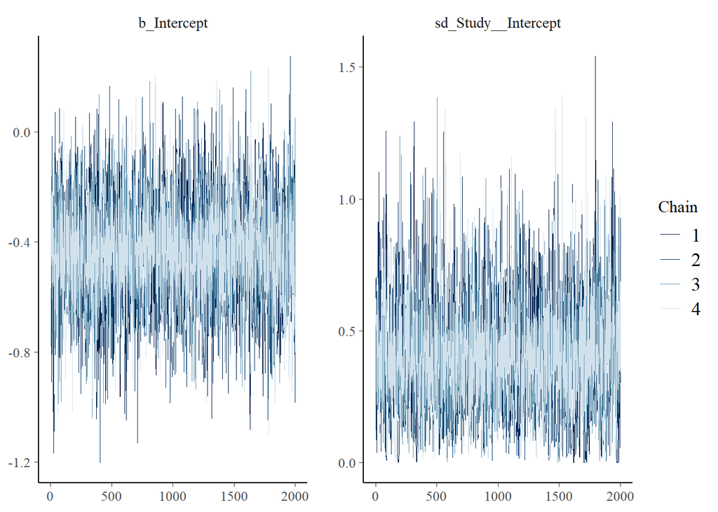

```r
brms::mcmc_plot(bmod, variable = c("b_Intercept","sd_Study__Intercept"), type = "trace")
```

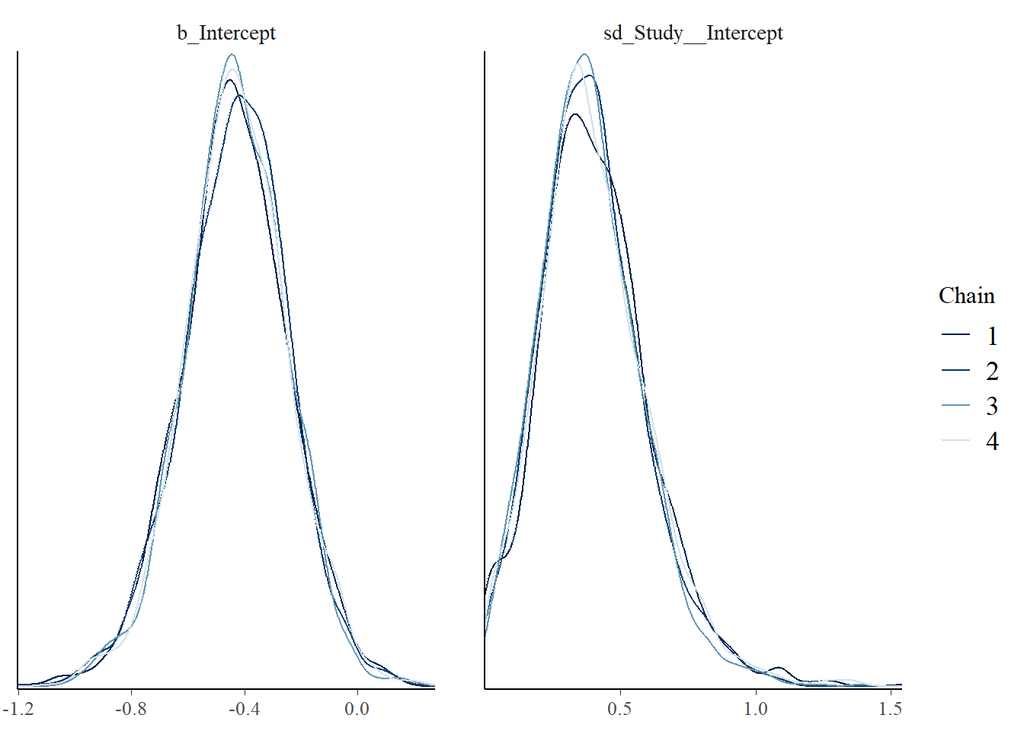

```r
brms::mcmc_plot(bmod, variable = c("b_Intercept","sd_Study__Intercept"), type = "dens_overlay")
```

## Prior specification

### Default priors

Without any prior specfication, `brms` uses default priors.

```r
get_prior(bmod)
```

```
                   prior     class      coef group resp dpar nlpar lb ub
 student_t(3, -0.4, 2.5) Intercept
    student_t(3, 0, 2.5)        sd                                  0
    student_t(3, 0, 2.5)        sd           Study                  0
    student_t(3, 0, 2.5)        sd Intercept Study                  0
       source
      default
      default
 (vectorized)
 (vectorized)
```

### Suggest your own prior

```r
priors <- c(prior(normal(0,1), class = Intercept),
            prior(cauchy(0,0.5), class = sd))
```

### Choose prior

- Overall effect size $\mu$

Default:

$$\frac{\mu + 0.4}{2.5} \sim t(3)$$

My own:

$$\mu \sim N(0,1)$$

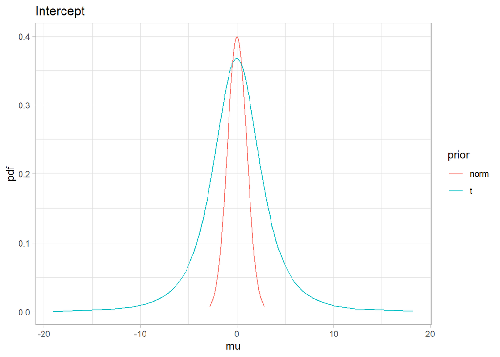

- Between-study heterogeneity $\tau$

My own:

$$|\tau| \sim Cauchy(0,0.5)$$

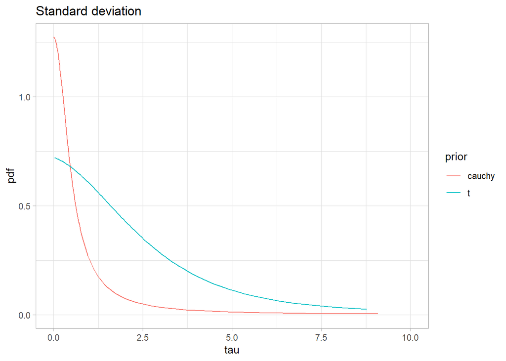

### Run analysis with your own prior

```r
bmod_myown <- brm(y|se(se) ~ 1 + (1|Study),
             data = sol,
             prior = priors, # user added priors
             chains = 4, # number of chains in mcmc sampline
             iter = 4000, # number of iterations in mcmc sampling
             file = "models/bmod_myown_priors")
```

### See results and check convergence

```r
(s_bmod_myown <- summary(bmod_myown)) # we use parentheses to show the results at the same time it is saved into an object
```

```
 Family: gaussian
  Links: mu = identity; sigma = identity
Formula: y | se(se) ~ 1 + (1 | Study)
   Data: sol (Number of observations: 11)
  Draws: 4 chains, each with iter = 4000; warmup = 2000; thin = 1;
         total post-warmup draws = 8000

Multilevel Hyperparameters:
~Study (Number of levels: 11)
              Estimate Est.Error l-95% CI u-95% CI Rhat Bulk_ESS Tail_ESS
sd(Intercept)     0.34      0.17     0.04     0.71 1.00     3098     3020

Regression Coefficients:
          Estimate Est.Error l-95% CI u-95% CI Rhat Bulk_ESS Tail_ESS
Intercept    -0.41      0.17    -0.76    -0.07 1.00     5685     4667

Further Distributional Parameters:
      Estimate Est.Error l-95% CI u-95% CI Rhat Bulk_ESS Tail_ESS
sigma     0.00      0.00     0.00     0.00   NA       NA       NA

Draws were sampled using sampling(NUTS). For each parameter, Bulk_ESS
and Tail_ESS are effective sample size measures, and Rhat is the potential
scale reduction factor on split chains (at convergence, Rhat = 1).
```

### Various plotting to check convergence

```
No divergences to plot.
```

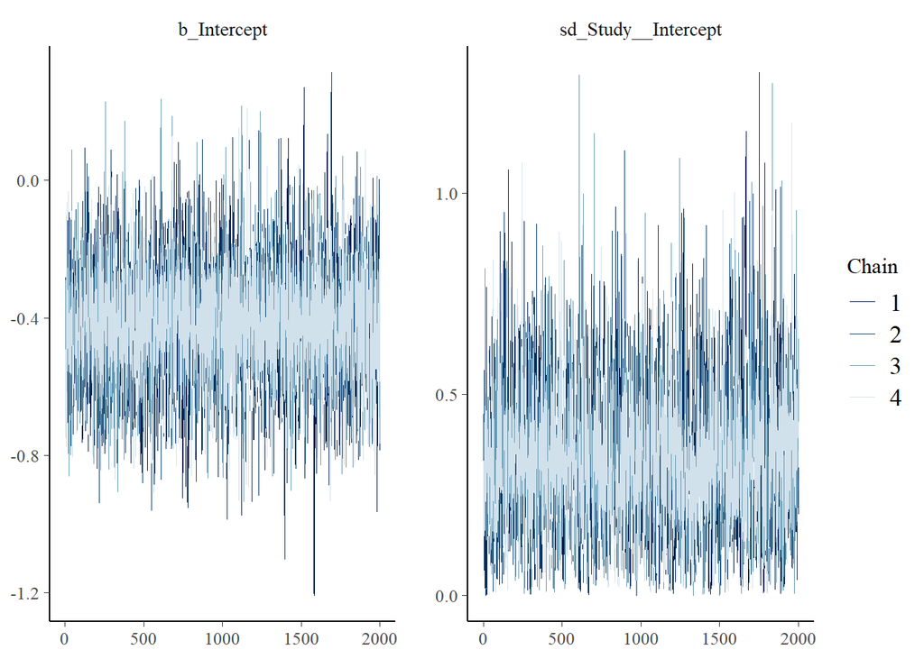

```r
brms::mcmc_plot(bmod_myown, variable = c("b_Intercept","sd_Study__Intercept"), type = "trace")
```

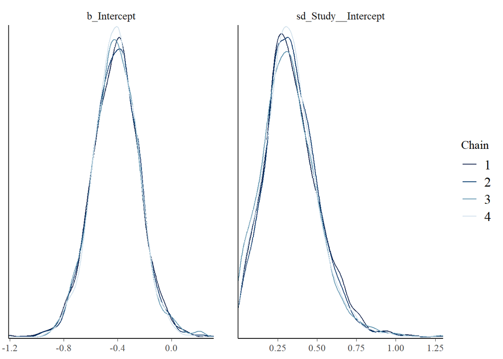

```r
brms::mcmc_plot(bmod_myown, variable = c("b_Intercept","sd_Study__Intercept"), type = "dens_overlay")
```

### Various plotting of posterior distributions

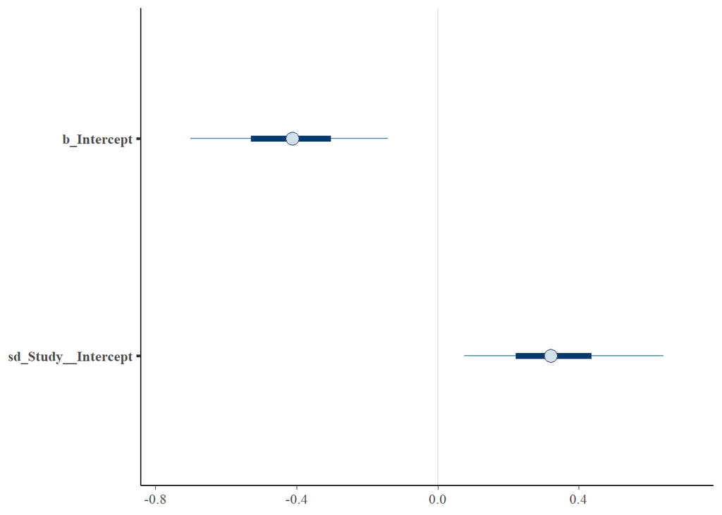

```r
brms::mcmc_plot(bmod_myown, variable = c("b_Intercept","sd_Study__Intercept"))
```

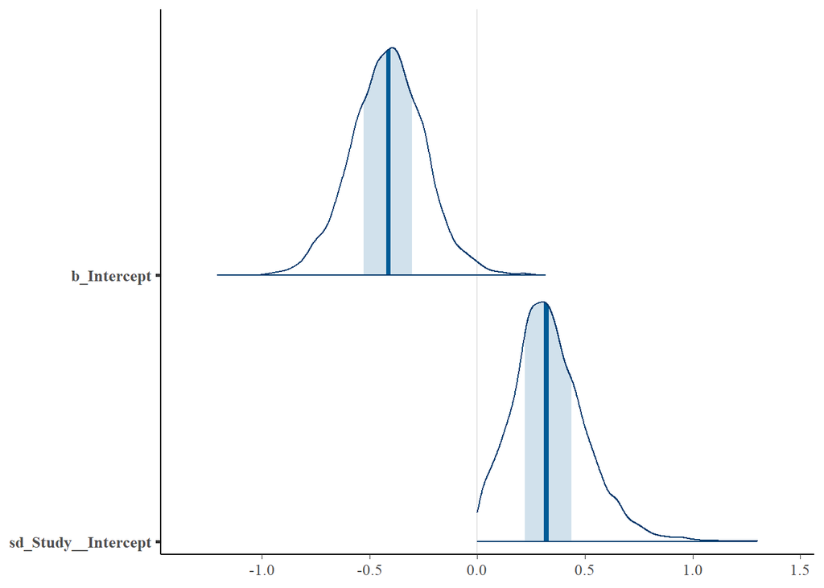

```r
brms::mcmc_plot(bmod_myown, variable = c("b_Intercept","sd_Study__Intercept"), type = "areas")
```

### Extract posterior samples

```r
post.samples <- brms::posterior_samples(bmod_myown, c("b_Intercept", "sd_Study__Intercept")) # extract posterior sample from mcmc sampling
names(post.samples) <- c("mu", "tau") # assign better names to sampled parameters
```

## Compare results

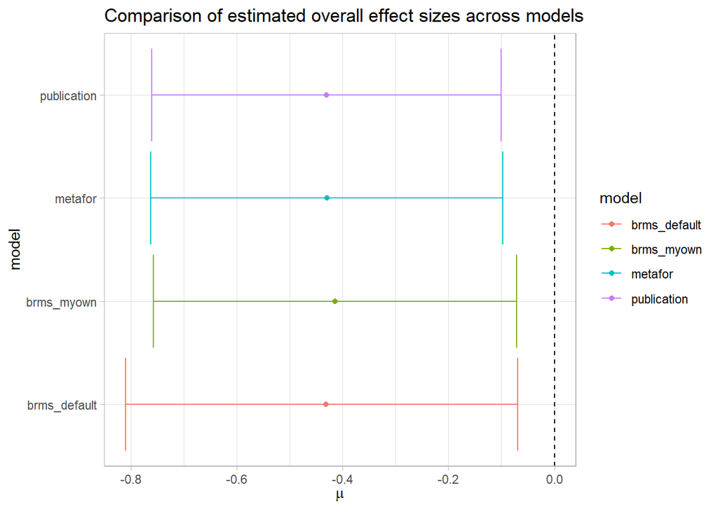

```r
rbind(df,
data.frame(mu=rmod$beta,lower=rmod$ci.lb, upper = rmod$ci.ub, model="metafor"),
data.frame(mu=s_bmod$fixed$Estimate,lower=s_bmod$fixed$`l-95% CI`, upper = s_bmod$fixed$`u-95% CI`, model="brms_default"),
data.frame(mu=s_bmod_myown$fixed$Estimate,lower=s_bmod_myown$fixed$`l-95% CI`, upper = s_bmod_myown$fixed$`u-95% CI`, model="brms_myown")) %>%
  ggplot(aes(x=mu,y=model,col=model)) +
  geom_point() +
  geom_errorbarh(aes(y=model,xmin=lower, xmax=upper)) +
  geom_vline(xintercept=0,linetype="dashed") +
  theme_light() +
  xlab(expression(mu)) +
  labs(title="Comparison of estimated overall effect sizes across models")
```

## Decision analysis

Should I shower or not?

Trade-off: Shower result in better sleep, but is can be problematic for the skin and consumes warm water.

Difference in utility when taking a shower compared to not taking a shower:

$$\Delta(\mu) = 1-\exp(\mu)$$

The Bayes optimal decision is the one that maximises the expected utility. Here, showering is optimal if the difference in utility is larger than 0.

Utility from showering before bedtime is uncertain considering uncertainty in the estimated overall effect size of the difference in Sleep Onset Latency.

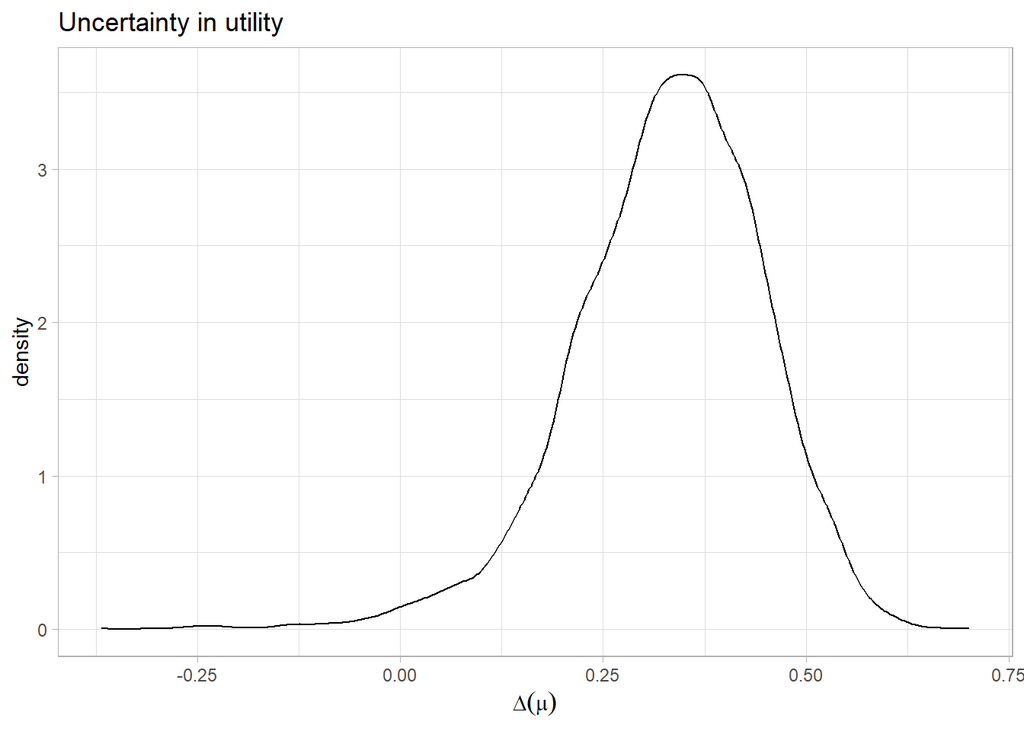

```r
df_decision_analysis <- data.frame(utility = 1 - exp(post.samples$mu))

df_decision_analysis %>%
      ggplot(aes(x = utility)) +
  geom_density() +
  xlab(expression(Delta(mu))) +
  theme_light() +
  labs(title="Uncertainty in utility")
```

The expected utility is 0.33.

**Conclusion**

I performed a Bayesian Evidence Synthesis integrating evidence from multiple studies into a decision analysis of the utility of taking a shower before going to bed.

My results shows that showering before bedtime will help you to quicker fall asleep.

## References

Bürkner, Paul-Christian. 2017. “brms: An R Package for Bayesian Multilevel Models Using Stan.” *Journal of Statistical Software* 80 (1): 1–28. https://doi.org/10.18637/jss.v080.i01.

Haghayegh, Shahab, Sepideh Khoshnevis, Michael H Smolensky, Kenneth R Diller, and Richard J Castriotta. 2019. “Before-Bedtime Passive Body Heating by Warm Shower or Bath to Improve Sleep: A Systematic Review and Meta-Analysis.” *Sleep Medicine Reviews* 46: 124–35.

Viechtbauer, Wolfgang. 2010. “Conducting Meta-Analyses in R with the metafor Package.” *Journal of Statistical Software* 36 (3): 1–48. https://doi.org/10.18637/jss.v036.i03.